# Project 3 First Draft

Jing Li

### Introduction

This project aims at analyzing the current job market. To be more specific, the focus is on full time data scientist/analyst positions. As the need for data scientist boosts recently, we are curious about the corresponding skill sets；would companies prefer python user or R user? Are old-school programming languages such as Perl really needed for the current job market?

Other than programming and other technical backgrounds, we will also take soft skill requirement into consideration. Meanwhile, we are also interested in knowing some company backgrounds. Geographically, does west coast more likely to hire data scientists? In terms of industry, do tech companies have more openings for data scientists? Does the skill requirement for data scientist differ based on industry variaty? Hopefully, we have enough confidence to answer those questions at the end of this project and at the mean time, help job seekers to better equip themselves for career as data scientists.

### Hypothesis

- Technical companies like google and facebook are more likely to hire data scientists due to their data capacity.
- West coast is more likely to hire data-related talents since the majority of tech companies are located at west coast.
- Increasing number of companies now require R as the primary language to process data instead of Python or Perl.

### Approach

In our cases, Monster will be used as primary sources to obtain the required data. Selector Gadget, a Google Chrome application, is used for obtaining the html xpath. Job title, company name, geographical location, industry as well as required skills are obtained from the website. In order to avoid bias, we only take fulltime data scientist position into consideration.

In terms of limitations, since Monster’s job posts may have different formats, data can only be extracted from the original Monster format. In order to solve this problem, observations that have missing industry and skill sets information will be automatically deleted. Meanwhile, duplication will be removed either in order to avoid bias.

### Result

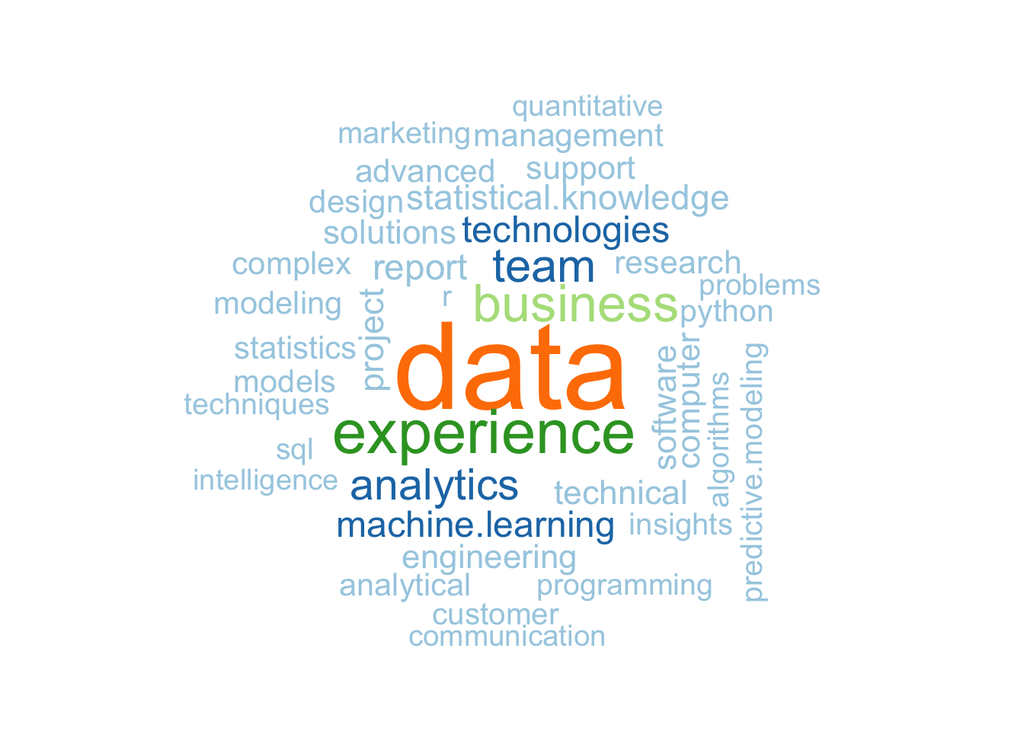

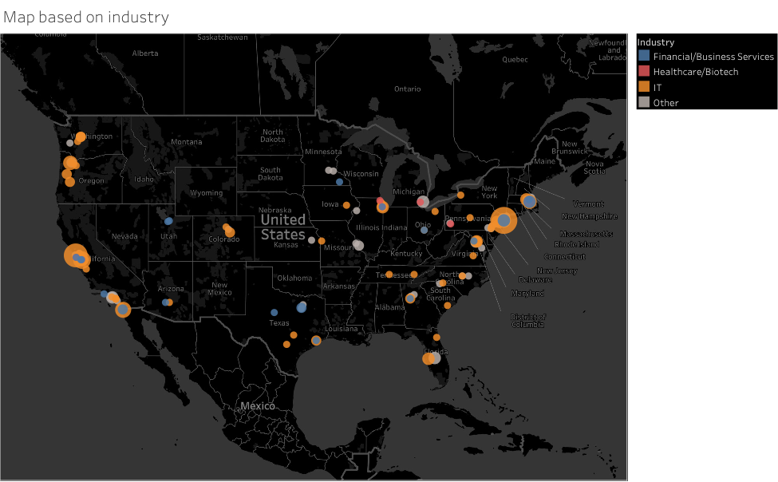

.

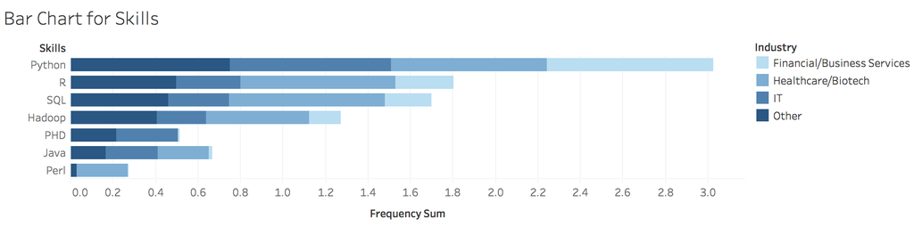

.

### Summary

- Hard skills differ by location/industry
- Soft skills
- Logistic regression model to predict skills for more senior positions?

### Limitation

- Insufficient Data
- Selection Bias

### Reference

Coordinate Data was obtained from: https://www.gaslampmedia.com/wp-content/uploads/2013/08/zip_codes_states.csv